# Lab 2-1

Converting, Streamlining, and Projecting Well Data for Merced County

Created by Madeline Brown

Updated 08/08/2022

University of California, Merced  
School of Engineering  
Spatial Analysis and Modeling (ENGR 180)

Responses to this assignment will be submitted in TWO documents.

#### Key deliverables are in RED.

#### File names are underlined

#### *Tools and key steps are italicized*

## Introduction

**Skills: Creating Projects,Data Conversion, Excel, Flat Files, Projections, Problem Solving**  
Case Study Scenario: You work at a local water utility as their GIS Specialist. The public has raised concern about well contamination, so your manager needs a map made for an upcoming meeting showing any contaminated wells within Merced County.  
Your hydrology coworkers gave you two “flat” files that you know you can import into ArcGIS Pro. These files include:  
• gama_edf_merced_index_dms.csv: The active ground monitoring well locations from the state Groundwater Ambient Monitoring and Assessment program (GAMA). [1]  
• gama_edf_merced_clean.csv: contaminant information for wells in Merced County, from GAMA. [2]  
You also have one Shapefile – collection of multiple files within a folder that all work together to display ONE dataset.  
• MercedCountyCAT- a zipped folder containing Merced County boundaries in polygon format in California Teale Albers projection [3]

### Part 1: Convert from DMS to DD in Excel

1. First you need to convert the WELL LOCATIONS from degree-minute-second (a notation that is convenient for humans, using paper maps) to decimal degrees (a more machine-readable format).
2. Use Excel to complete this conversion from DMS to DD. HINT: You can split data up into columns then “reassemble.”

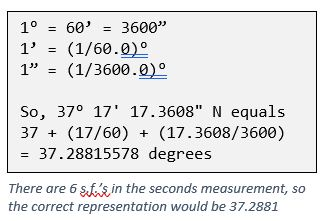

*Value Conversion*

Refer to the box above for a note about the conversion. For this exercise, retain as many bits of precision as possible, but do think about what the appropriate number of significant figures would be.  
c. Save the converted file as a new CSV with three columns: WellName, LongitudeDD, and LatitudeDD (in decimal degrees). Name your CSV – GAMAWellsDD. We will use this data shortly.

### Part 2: Prep Remote Server and ArcGIS Pro

1. As always, log into Classfiles first!
2. Download all datasets in Catcourses->Files->Lab2-1->Data to a folder in YOUR classfiles named CaseStudy2-1Data. Always bring over all project critical data before you begin. It’s frustrating to have to do mid-project! Unzip any zipped files, or else they won’t show up in Pro. Be sure to place your GAMAWellsDD.csv file in this folder too! A
3. Open ArcGIS Pro and sign into your ArcGIS Account (top right corner, your regular DUO info)
4. Be sure to use “Your ArcGIS organization’s URL” section. See Lab 0 instructions if you need a refresher.
5. Select *New* – *Blank Templates* – *Map*
6. Save your project as CaseStudy2-1 to your root (last name) Classfiles folder. ArcGIS Pro will automatically make a folder with the same name for you!
7. Every time you run a *Geoprocessing* tool, it will output to this location. Make sure the box for *Create a new folder* is checked.  
   Important! Don’t use spaces or special symbols when naming GIS related files!! EVER. Dashes and underscores are OK.

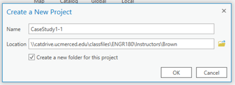

*Creating Project*

### Part 3: Opening shapefiles in ArcGIS Pro

ArcGIS Pro does not open files like other programs that you may be familiar with. To open a shapefile, first you must make a *Folder Connection* with the directory where your data reside.

1. Create a folder connection to the folder that holds the data you downloaded from CatCourses CaseStudy2-1Data. You can create folder connections under the *Add Data* button, found in the *Map Ribbon*, or through the *Catalog* pane on the right of the screen by right clicking *Folders* and *Add Folder Connection*.
2. Drag and drop MercedCountyCAT, into your map window in ArcGIS Pro. Experiment with rearranging the order of the data sets in the Table of Contents (the left sidebar with your layers), and experiment with toggling the layer visibility (with the checkboxes in the Table of Contents).
3. A Merced County polygon should show up in your map frame. It may have different default symbology. Click on the small polygon in the *Table of Contents* and change the symbology to a solid black outline with no fill.

[figure not shown]

*Merced County with black outline, no fill*

It is common to download data in a shapefile format or receive data as a shapefile from outside organizations. If you worked for SoCal Edison, you might receive a shapefile of transmission lines from PG & E. Shapefiles are low-tech and can be shared across GIS software. If you as a SoCal Edison employee edit the shapefile, it doesn’t change anything on PG & E’s side.

### Part 4: Confirming Projection Information

1. Right Click on your MercedCountyCAT layer and access the *Properties* (at the very bottom)
2. Go to *Source* -> *Spatial Reference*  
   • Screenshot the Spatial Reference portion for submission. This confirms our data is in an appropriate California-specific projection.  
   • In a written component, identify the PROJECTION used and describe why it is appropriate for mapping contaminated wells in Merced County. Google the projection name to gain additional information if you are unsure

### Part 5: Using Basemaps in ArcGIS Pro

ArcGIS Pro allows you to display your data as an overlay on a variety of maps provided by Esri’s web service. You can change your basemap under the *Basemap* button, found in the Map ribbon. Basemaps are useful for orienting yourself or providing context to data. Note: ArcGIS Pro may complain about different projections/coordinate systems when enabling different basemaps. Just make a note of it for now, the reason behind the warning will become clear after you learn more about the program.

1. Change your basemap to a different one besides the default. Pan Around. Change the basemap back to Topographic.  
   *HEY! Have you saved your project lately? Just like with Microsoft Word or other software, it’s good to save, save, and save often! ArcGIS Pro does not automatically save ANYTHING!*

### Part 6: Import Well Data

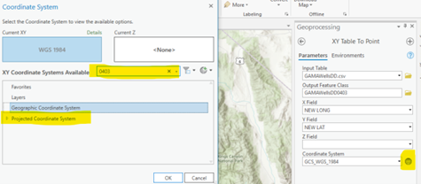

*Searching for Projections*

• The *XY Table to Point* tool will take the “flat file” information and place it onto your map as geospatial data in a *Feature Class* format. More on that later.  
• The layer will automatically be added to your *Table of Contents*. Right click on the layer, and *Zoom to Layer*…  
• Take a screenshot of your newly imported points- you’ll submit this in a side-by-side comparison after we adjust them in the next few steps.  
• Answer: Where are the well points showing up in your map display? Where *should* they be showing up based on the information from your coworker? Can you speculate on what is going on?  
This is a map projection issue. The software used the wrong *Spatial Reference* (Geoid, Ellipsoid, Datum, Projection, Projection Coordinate System…) when it placed the points.  
Projection issues are common, but frustrating! You return to your coworker and ask them about the original coordinates. Ah! They remember that those were NOT projected at all. Those were Geographic Coordinates. That means you can re-read them in unprojected, then project them to what we want.

### Part 8: Matching Projections: GCS to PCS

We now have two layers – MercedCountyCAT IS projected because it was given to us in a shapefile with a preexisting applied Projected Coordinate System of California Teale Albers. The GAMAWellsDDGCS layer is unprojected because we read it in with the GCS_WGS_1984 Geographic Coordinate System.

### Part 10: Correcting Projection Issues with Math

Your coworker has a flat file of coordinates and doesn’t know what they represent, only that they are in basic x and y coordinates and need to be converted to California Teale Albers. BUT! The GIS software you’d normally use is down! You’ll have to use Excel to complete the conversion efficiently.

In the olden days, pre-computers, if cartographers wanted maps to be projected differently, they had to do it by hand using spherical geometry!

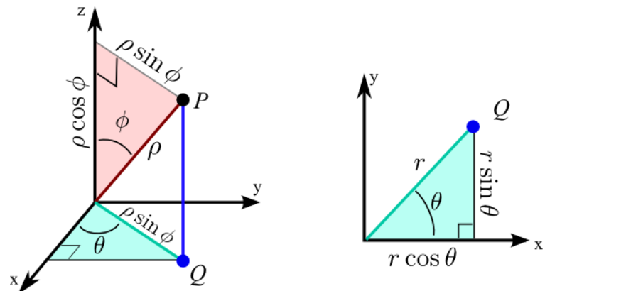

*Spherical Geometry*

These diagrams show us the conversion from spherical (see how the left image has x, y, AND z. 3 coordinates = 3-D globe. x and y on the right are for a flat, 2-D surface, like a map!).

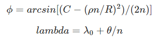

*Parent Equation*

given

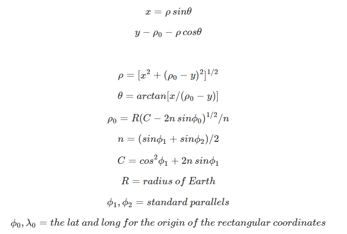

*Equation Components*

We can build equations into Excel columns and populate *constants* to determine *variables* just like high school math.

Hint: Some of your columns will utilize OTHER columns, eg convert to radians using =RADIANS(ColumnLetter#) and other Excel formula.

Populate the spreadsheet to determine your converted coordinates. Create a plot of the converted coordinates. What does it show? Submit the full spreadsheet, including the plot, as an additional attachment to your homework submission.